# Tsiaras_Milestone_Report

Athanasios K. Tsiaras

10-23-2018

# 1. Exploratory Analysis

## 1.1 Loading the data

Data is loaded from the datasets folder into tibble data frames. Then those frames are binded into a single one and each line of text is grouped by the file it came from. Keeping the data both in individual and in total variables helps in the analysis of different aspects of the data, as demonstrated below.

```r
# Setting the datasets folder as the working directory
setwd("~/Desktop/final")

# Loading the necessary packages
library(dplyr)
library(tidytext)
library(stopwords)
library(stringi)
library(tidyr)
library(ggplot2)
library(igraph)
library(ggraph)
library(ggpubr)
library(gridExtra)

# Reading files into tibble frames
fileName <- c('en_US/en_US.news.txt', 'en_US/en_US.blogs.txt', 'en_US/en_US.twitter.txt')

news <- readLines(fileName[1])
news <- data_frame(source='news', line = 1:length(news),text=tolower(news))


blogs <- readLines(fileName[2])
blogs <- data_frame(source='blogs', line = 1:length(blogs),text=tolower(blogs))


twit <- readLines(fileName[3])
twit <- data_frame(source='twitter', line = 1:length(twit),text=tolower(twit))

# Merging files into one data frame for better data manipulation
all_text <- bind_rows(list(news,blogs,twit))
all_text$source <- as.factor(all_text$source)
```

## 1.2 Exploratory Analysis

### 1.2.1 Basic Data Summary

Creating a report summarizing the number of words, lines and most popular words by file. This helps get a first feel of the data and is crucial to the development of the prediction algorithm.

```r
# Basic line and word summaries
source_text <- all_text %>%
        unnest_tokens(word, text)

line_word_info <- as.data.frame(list(
        'Blogs' = c(
                        dim(source_text[source_text$source=='news',])[1],
                        dim(all_text[all_text$source=='news',])[1],
                        round(mean(nchar(as.character(blogs$text))))
                ),

        'News' = c(
                                dim(source_text[source_text$source=='blogs',])[1],
                                dim(all_text[all_text$source=='blogs',])[1],
                                round(mean(nchar(as.character(news$text))))
                ),

        'Twitter' = c(
                                dim(source_text[source_text$source=='twitter',])[1],
                                dim(all_text[all_text$source=='twitter',])[1],
                                round(mean(nchar(as.character(twit$text))))
                )))

row.names(line_word_info) <- c('Number of words', 'Number of lines', 'Average line length')

numbers=c('1','2','3','4','5','6','7','8','9','10')

source_words <- source_text %>%
        count(source, word, sort=TRUE) %>%
        filter(!substring(word,1,1) %in% numbers==TRUE) %>%
        filter(!word %in% stop_words$word) %>%
        ungroup()

news_words <- arrange(source_words[source_words$source=='news',][1:20,], -n)
blogs_words <- arrange(source_words[source_words$source=='blogs',][1:20,], -n)
twit_words <- arrange(source_words[source_words$source=='twitter',][1:20,], -n)

g_news <- ggplot(news_words, aes(x = reorder(word, -n), y = n)) +
        labs(title='Most frequent words in News', x='Word', y='Frequency')+
        geom_bar(fill = "#0073C2FF", stat = "identity") +
        theme_light()

g_blogs <- ggplot(blogs_words, aes(x = reorder(word, -n), y = n)) +
        geom_bar(fill = "#0073C2FF", stat = "identity") +
        labs(title='Most frequent words in Blogs', x='Word', y='Frequency') +
        theme_light()

g_twit <- ggplot(twit_words, aes(x = reorder(word, -n), y = n)) +
        geom_bar(fill = "#0073C2FF", stat = "identity") +
        labs(title='Most frequent words in Twitter', x='Word', y='Frequency') +
        theme_light()


words_by_source <- as.data.frame(cbind('twitter'=twit_words[,2:3],
                                       'news'=news_words[,2:3],
                                       'blogs'=blogs_words[,2:3]))

print(line_word_info)
```

[output not shown]

```r
print(words_by_source)
```

```
##    twitter.word twitter.n news.word news.n blogs.word blogs.n
## 1          love    106721      time  57062       time   90918
## 2           day     91710    people  47666     people   59574
## 3            rt     89537      city  37953        day   52372
## 4          time     76794    school  35498       love   45230
## 5           lol     70133      game  34949       life   41251
## 6        people     52040   percent  34690       it’s   38657
## 7         happy     48998       day  31901      world   29305
## 8        follow     48104   million  30914        i’m   29189
## 9       tonight     44699      home  30601      don’t   28389
## 10        night     41169    county  30172       book   28147
## 11         hope     35557      team  28952       home   27944
## 12         life     33934    season  28494       week   26317
## 13           im     30674    police  27094       feel   24451
## 14      twitter     30634       u.s  23434        god   22368
## 15         game     30615       p.m  23336        lot   21550
## 16         week     29126    public  22744       read   21380
## 17     tomorrow     28529      week  22652       days   20160
## 18         wait     27225        st  22101     family   20007
## 19         haha     27203      play  21130       blog   19644
## 20      morning     26487    center  20369        bit   19637
```

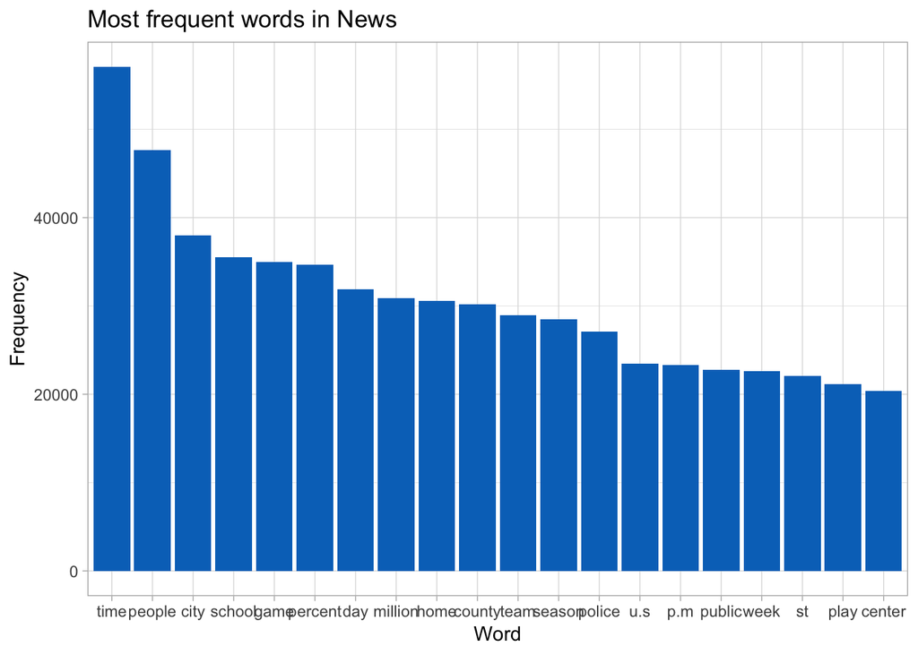

```r
print(g_news)
```

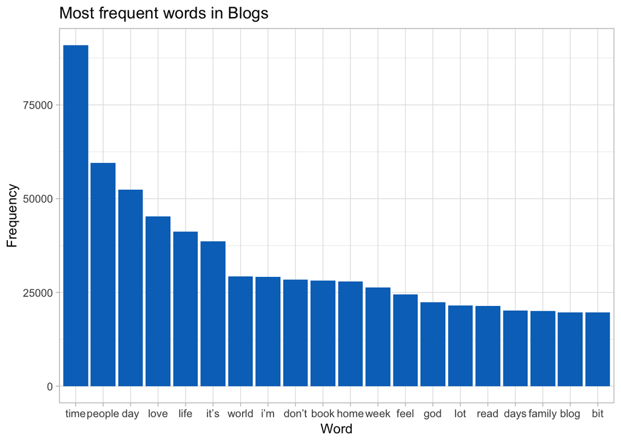

```r
print(g_blogs)
```

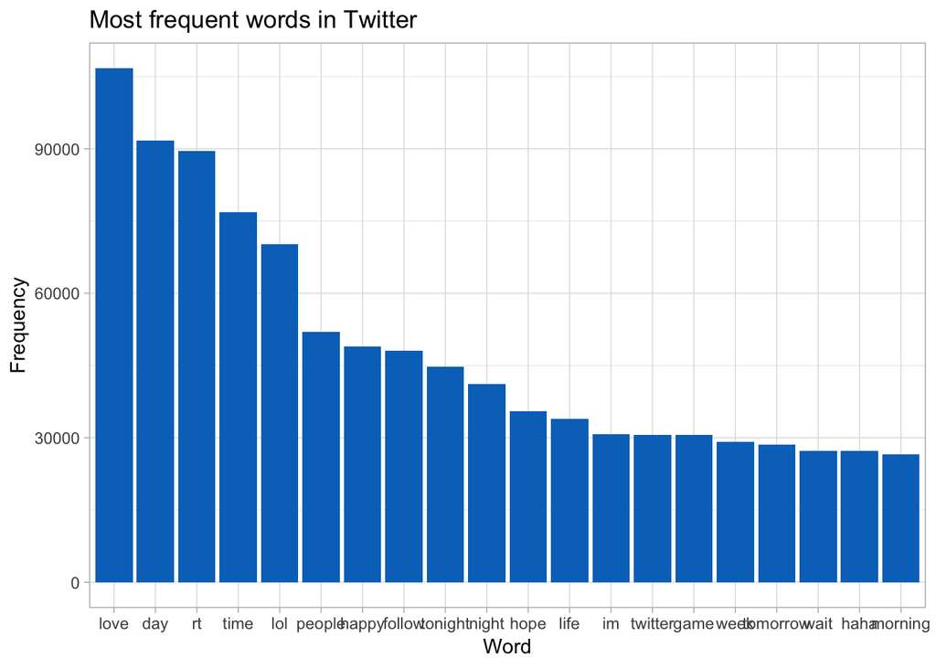

```r
print(g_twit)
```

### 1.2.2 Tokenization, bigram-trigram analysis

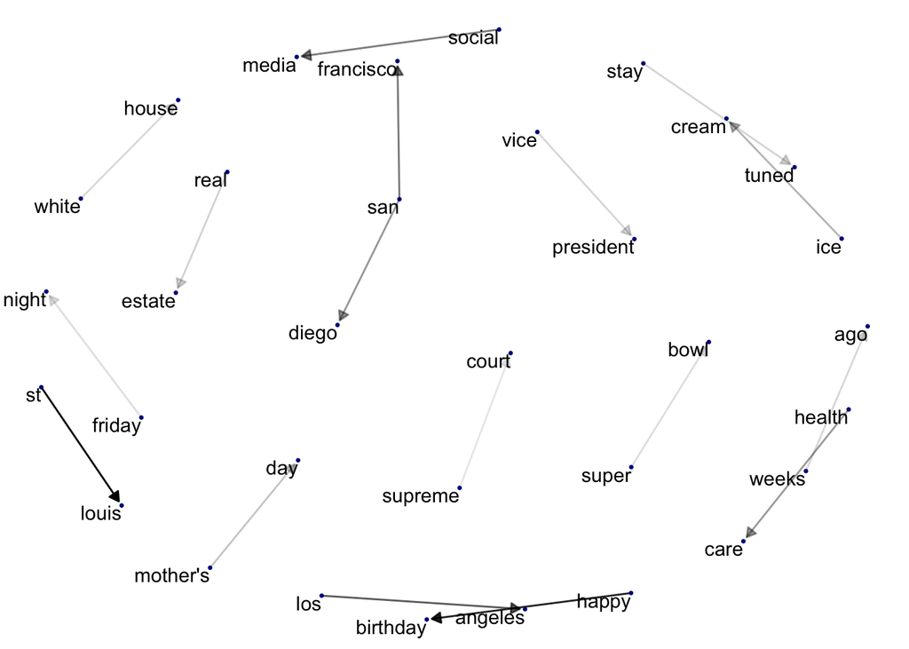

```r
#==================================Tokenizing by n-gram=================================

# How frequently do 2 words appear together?

bigram <- all_text %>%
        unnest_tokens(bigram, text, token = "ngrams", n = 2)

# Most of the bigrams are common words useless for analysis ex. 'the', 'or', 'and', 'to
# We filter those out along with any possible NA values

bigram <- bigram %>%
        filter(!is.na(bigram)) %>%
        separate(bigram, c("first_word", "second_word"), sep = " ")

bigram_filt <- bigram %>%
        filter(!substring(first_word,1,1) %in% numbers==TRUE) %>%
        filter(!substring(second_word,1,1) %in% numbers==TRUE) %>%
        filter(!first_word %in% stop_words$word) %>%
        filter(!second_word %in% stop_words$word)

bigram_united <- bigram_filt %>%
        unite(bigram, first_word, second_word, sep = " ")

bigram_counts <- bigram_united %>% count(bigram, sort=TRUE)

bigram_graph <- bigram_counts %>%
        separate(bigram, c("first_word", "second_word"), sep = " ") %>%
        filter(n > 2700) %>%
        graph_from_data_frame()

arr <- grid::arrow(type = "closed",
                   length = unit(.2, "cm"))

set.seed(10-20-2018)

ggraph(bigram_graph, layout = "kk") +
        geom_edge_link(aes(edge_alpha = n), show.legend = FALSE,
                       arrow = arr, end_cap = circle(.1, 'cm')) +
        geom_node_point(color = "darkblue", size = .5) +
        geom_node_text(aes(label = name), vjust = 1, hjust = 1) +
        theme_void()
```

```r
# How frequently do 3 words appear together?

trigram <- all_text %>%
        unnest_tokens(trigram, text, token = "ngrams", n = 3)

trigram <- trigram[complete.cases(trigram),] %>%
        separate(trigram, c("first_word", "second_word", "third_word"), sep = " ")

trigram_filt <- trigram %>%
        filter(!substring(first_word,1,1) %in% numbers==TRUE) %>%
        filter(!substring(second_word,1,1) %in% numbers==TRUE) %>%
        filter(!substring(third_word,1,1) %in% numbers==TRUE) %>%
        filter(!first_word %in% stop_words$word) %>%
        filter(!second_word %in% stop_words$word) %>%
        filter(!third_word %in% stop_words$word)

trigram_united <- trigram_filt %>%
        unite(trigram, first_word, second_word, third_word, sep = " ")

trigram_counts <- trigram_united %>% count(trigram, sort=TRUE)

print(trigram_counts)
```

```
## # A tibble: 4,600,036 x 2
##    trigram                    n
##    <chr>                  <int>
##  1 happy mothers day       1768
##  2 happy mother's day      1666
##  3 president barack obama  1481
##  4 cinco de mayo           1349
##  5 world war ii            1161
##  6 st louis county         1081
##  7 gov chris christie       923
##  8 st patrick's day         665
##  9 martin luther king       649
## 10 love love love           582
## # ... with 4,600,026 more rows
```

# 2.Next-steps, Prediction Algorithm implementation

A very staight-forward approach on the prediction app implementation is to base its predictions on the n-grams. When a word is inserted by the user, the algorithm will search for the most possible next one to appear, based on the, if there are any, other words and the n-grams and, if there are not, base on the most possible unigrams.